# A2 Comp1 Gabriel Hilu de Barros Moreira

O principal objetivo deste trabalho é demonstrar a relação de indicadores econômicos com a notas dos alunos no ENEM em cada matéria específica. Desta forma, busca-se identificar de fato se há um déficit do ensino brasileiro e apontar onde há o provável impacto na qualidade do serviço prestado

Inicialmente foi escolhida a base de dados do ENEM, disponível na no site do Inep através do link ( https://www.gov.br/inep/pt-br/acesso-a-informacao/dados-abertos/microdados/enem ). A razão de sua escolha se deu decorrente da vasta gama de informações disponíveis, a importância das mesmas e, principalmente, pelas análises que poderiam ser feitas com os dados disponíveis

```python
#Importar os pacotes

import pandas as pd
import matplotlib.pyplot as plt
import seaborn as sns
```

```python
#Ler a base de dados
df=pd.read_csv('MICRODADOS_ENEM_2022.csv', encoding = 'ISO-8859-1',sep=';')
```

Em termos de códigos, a primeira etapa realizada foi ler e limpar a base de dados. Foram retirados os dados que não eram de interesse do trabalho: pessoas que não teriam o ensino médio completo no ano de realização do ENEM; aqueles que faltaram um dia de prova e consequentemente ficaram com “NaN” aparecendo como variável na nota do ENEM. Note-se que se esses dados fossem mantidos iriam contaminar toda a análise. Ainda, foi simplificado a data frame criando o df_a1, em qual todas as análises são baseadas, para facilitar a testagem do código

```python
df=df[df['TP_ST_CONCLUSAO'].isin([1,2])] ###retirando quem esta fazendo o enem para '''treinar'''
```

```python
df_a1=df[['TP_ESCOLA','NU_NOTA_CN','NU_NOTA_CH','NU_NOTA_LC','NU_NOTA_MT','NU_NOTA_REDACAO','Q005','Q006','Q007','Q008','Q009','Q010','Q011','Q012','Q013','Q014','Q015','Q016','Q017','Q018','Q025']]
df_a1=df_a1.dropna(axis=0) ### não era interessante ver quem faltou a prova
```

```python
def muda_quartos(x):      #melhor ter os dados em números e não em A B C D E
    #if x == 'A':
    #    return 0.0001 linha foi reitirada pois mais atrapalhava que ajudava a análise
    if x == 'B':
        return 1
    if x == 'C':
        return 2
    if x == 'D':
        return 3
    if x == 'E':
        return 4

df_a1['Q009']=df_a1['Q009'].apply(muda_quartos)
```

```python
def muda_dias_empregado(x):            #melhor ter os dados em números e não em A B C D E
    if x == 'A':
       return 0
    if x == 'B':
        return 1.5
    if x == 'C':
        return 3.5
    if x == 'D':
        return 6


df_a1['Q007']=df_a1['Q007'].apply(muda_dias_empregado)


def muda_internet(x):            #melhor ter os dados em números e não em A B
    if x == 'A':                 # 0 será não e 1 será sim
       return 0
    if x == 'B':
        return 1

df_a1['Q025']=df_a1['Q025'].apply(muda_internet)
```

```python
#facilitar printar resultados

def porcentagem(agrupado,quantas,texto):
    for i in range (1,quantas+1):
      print(f'Diferença percentual entre as notas do grupo\ncom 0 {texto} e {agrupado.iloc[i].name} {texto}')

      print(1-(agrupado.iloc[0]/agrupado.iloc[i]),'\n\n\n')
```

```python
df_a1=df_a1.drop(df_a1[df_a1['Q009'] == 'A'].index) ###https://saturncloud.io/blog/how-to-remove-rows-with-specific-values-in-pandas-dataframe/#:~:text=Another%20method%20to%20remove%20rows,value%20we%20want%20to%20remove.
               #retirar pois acredito que  esses dados estajam contaminados ''' pessoas de escolas privadas contando como sem quarto em casa'''??? ou não???
               #principal motivo na realidade seria para que a variavel peesoas/quarto nao fica estranha
```

```python
#Criando a variável comodidades

df_a1['Comodidades'] = 10
i=9
df_a1.loc[df_a1['Q008'] == 'A', 'Comodidades'] = df_a1['Comodidades']-1

while i<18:
    i+=1
    df_a1.loc[df_a1[f'Q0{i}'] == 'A', 'Comodidades'] = df_a1['Comodidades']-1

df_a1=df_a1.drop('Q008',axis=1)
df_a1=df_a1.drop(df_a1.iloc[:,10:19],axis=1)
```

```python
#criando variavel para correlação depois

df_a1['Pessoas/Quartos']=df_a1['Q005'] / df_a1['Q009']
df_a1
```

|  | TP_ESCOLA | NU_NOTA_CN | NU_NOTA_CH | NU_NOTA_LC | NU_NOTA_MT | NU_NOTA_REDACAO | Q005 | Q006 | Q007 | Q009 | Q025 | Comodidades | Pessoas/Quartos |
| --- | --- | --- | --- | --- | --- | --- | --- | --- | --- | --- | --- | --- | --- |
| 2 | 1 | 421.1 | 546.0 | 498.8 | 565.3 | 760.0 | 2 | B | 0.0 | 2.0 | 1 | 3 | 1.000000 |
| 3 | 1 | 490.7 | 388.6 | 357.8 | 416.0 | 320.0 | 3 | A | 0.0 | 3.0 | 1 | 4 | 1.000000 |
| 7 | 1 | 398.1 | 427.3 | 400.2 | 404.9 | 440.0 | 5 | B | 0.0 | 2.0 | 1 | 5 | 2.500000 |
| 9 | 1 | 467.5 | 461.0 | 466.7 | 435.3 | 360.0 | 2 | B | 0.0 | 1.0 | 1 | 2 | 2.000000 |
| 11 | 3 | 458.7 | 539.8 | 488.2 | 456.8 | 940.0 | 4 | B | 0.0 | 2.0 | 1 | 3 | 2.000000 |
| ... | ... | ... | ... | ... | ... | ... | ... | ... | ... | ... | ... | ... | ... |
| 3476095 | 1 | 444.5 | 504.4 | 489.5 | 423.6 | 580.0 | 4 | C | 0.0 | 1.0 | 1 | 6 | 4.000000 |
| 3476097 | 1 | 536.1 | 633.2 | 584.0 | 596.3 | 740.0 | 1 | D | 0.0 | 1.0 | 1 | 3 | 1.000000 |
| 3476098 | 2 | 487.6 | 495.6 | 545.5 | 597.4 | 580.0 | 2 | B | 0.0 | 1.0 | 1 | 4 | 2.000000 |
| 3476099 | 1 | 512.5 | 524.8 | 546.8 | 432.0 | 520.0 | 3 | B | 0.0 | 2.0 | 0 | 4 | 1.500000 |
| 3476102 | 2 | 527.9 | 627.0 | 583.3 | 637.1 | 660.0 | 4 | G | 0.0 | 3.0 | 1 | 7 | 1.333333 |

1920850 rows × 13 columns

```python
df_publicas=df_a1[df_a1['TP_ESCOLA'].isin([2])] ###sep escolas
df_privadas=df_a1[df_a1['TP_ESCOLA'].isin([3])]
df_vazio=df_a1[df_a1['TP_ESCOLA'].isin([1])]



df_renda_d_e=df_a1[df_a1['Q006'].isin(['A','B','C','D','E'])] ###sep renda por classes a b c d e
df_renda_c=df_a1[df_a1['Q006'].isin(['F','G','H','I'])]
df_renda_b=df_a1[df_a1['Q006'].isin(['J','K','L','M','N','O','P'])]
df_renda_A=df_a1[df_a1['Q006'].isin(['Q'])]


df_a1=df_a1.drop('Q006',axis=1)  #renda irei trabalhar separado para nao estragar o heat map de correc sem colocar numeric_only
```

A primeira análise realizada foi a mais óbvia, qual seja, “Comparação da média de notas entre escolas públicas e privadas”. As notas relativas à opção “não informou tipo de escola” aparecem com suposta aleatoriedade, devido ao fato de da nota ser um meio termo do setor privado e do público. Neste ponto, já ‘e observada uma maior discrepância na área da matemática e da redação em comparação a áreas de ciências humanas, ciências da natureza e redação

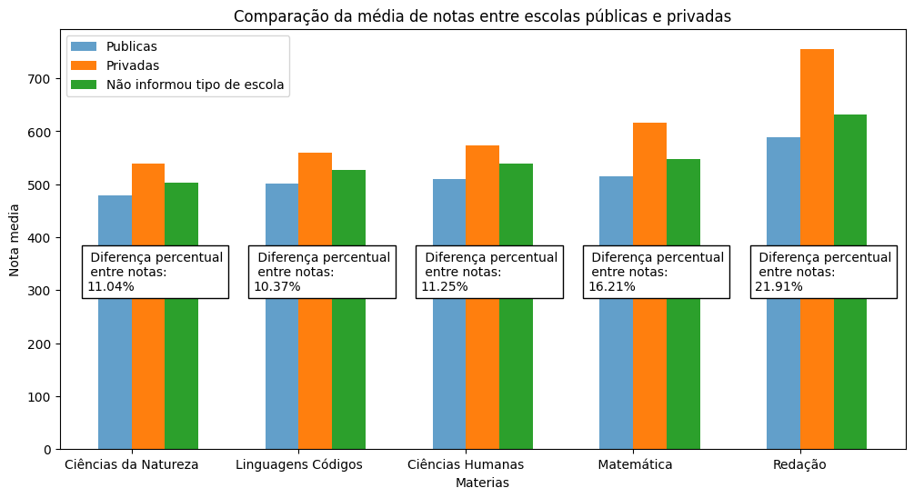

```python
notas_pp = ['NU_NOTA_CN', 'NU_NOTA_LC', 'NU_NOTA_CH', 'NU_NOTA_MT', 'NU_NOTA_REDACAO']
media_publicas = df_publicas[notas_pp].mean()        #tirando as medias
media_privadas = df_privadas[notas_pp].mean()
media_vazio = df_vazio[notas_pp].mean()
nomes=['Ciências da Natureza','Linguagens Códigos', 'Ciências Humanas',' Matemática','Redação']

hh_triste=(1-(media_publicas/media_privadas))*100


plt.figure(figsize=(12, 6))
bar_width = 0.20
index = range(len(notas_pp))

plt.bar(index, media_publicas, bar_width, label='Publicas', alpha=0.7)
plt.bar([i + bar_width for i in index], media_privadas, bar_width, label='Privadas')
plt.bar([i + bar_width*2 for i in index], media_vazio, bar_width, label='Não informou tipo de escola') #mechendo um pouco no codigo do chatGpt

j=-117/100
for a in hh_triste:
    j+=1
    plt.text(j,300,f' Diferença percentual\n entre notas:\n{a:.2f}%',
             bbox=dict(facecolor='white', alpha=1))

plt.xlabel('Materias')
plt.ylabel('Nota media')
plt.title('Comparação da média de notas entre escolas públicas e privadas')
plt.xticks([i + bar_width/2 for i in index], nomes,rotation=0)
plt.legend()
plt.show()

#chat gpt em partes(partes pequenas no fim )
```

Suponho que quem não informa seja uma aleatoridade, uma vez que as medias estão na media Aqui fica visível que existe sim uma relacao entre qual tipo de escola se estuda e a sua nota do ENEM em media

# E voltar quando for visto outro aviso semelhante a esse e as células não estiverem comentadas. Trabalho foi feito antes de ser falado o limite de tamanho.

A próxima comparação foi feita principalmente para analisar o quanto cada classe social é afetada pelas inúmeras desvantagens que um aluno de menor poder aquisitivo enfrenta em comparação aos de maior. E, mais uma vez, fica clara a diferença de oportunidade em todas as áreas de conhecimento aferidas na prova. No contexto, a diferença fica mais alarmante novamente nas disciplinas de matemática e da redação

```
17.91309620544389
15.042665838873203
16.58510096914775
25.885930910130362
25.544676014398494
```

[figure not shown]

```python
# notas_pp = ['NU_NOTA_CN', 'NU_NOTA_LC', 'NU_NOTA_CH', 'NU_NOTA_MT', 'NU_NOTA_REDACAO']
# media_a = df_renda_A[notas_pp].mean()             #tirando as medias
# media_b = df_renda_b[notas_pp].mean()
# media_c = df_renda_c[notas_pp].mean()
# media_de= df_renda_d_e[notas_pp].mean()
# nomes=['Ciências da Natureza','Linguagens Códigos', 'Ciências Humanas',' Matemática','Redação']

# hh=(1-(media_de/media_a))*100


# plt.figure(figsize=(12, 6))              #plotando
# bar_width = 0.20
# index = range(len(notas_pp))

# plt.bar(index, media_a, bar_width, label='Classe A', alpha=0.7)
# plt.bar([i + bar_width for i in index], media_b, bar_width, label='Classe B')
# plt.bar([i + bar_width*2 for i in index], media_c, bar_width, label='Classe C')
# plt.bar([i + bar_width*3 for i in index], media_de, bar_width, label='Classe D e E')   #mechendo um pouco no codigo do chatGpt
# j=-117/100  #é possivel mudar o j manualmente
# for a in hh:
#     j+=1
#     plt.text(j,300,f' Diferença percentual\n entre notas extremas:\n{1-a:.2f}%',
#              bbox=dict(facecolor='white', alpha=1))
#     print(a)

# plt.xlabel('Materias')
# plt.ylabel('Nota media')
# plt.title('Comparação da média de notas entre classes socias')
# plt.xticks([i + bar_width/2 for i in index], nomes,rotation=0)
# plt.legend()

# #https://matplotlib.org/3.5.3/api/_as_gen/matplotlib.pyplot.html
```

Aqui é visto que a renda da familia está relacionada a sua nota esperada no ENEM, provavelmente devido ao fato de quanto menor a renda menor a probabilidade do aluno ter acesso a uma escola privada, acesso a internet, acesso a um maior número de facilitadores de vida e em geral menos tempos de lazer ou um lazer de menor qualidade.

```
Quantas pessoas em cada grupo:
Q007
0.0    1765876
1.5      87123
6.0      48711
3.5      19140
Name: count, dtype: int64



Media de notas em materias especificas de cada grupo:
      NU_NOTA_CN  NU_NOTA_LC  NU_NOTA_CH  NU_NOTA_MT  NU_NOTA_REDACAO
Q007
0.0   493.717430  517.038630  527.144961  535.718036       619.844134
1.5   540.143054  553.828938  570.627595  612.924506       712.875360
3.5   538.060538  551.257811  568.504180  613.623830       713.749216
6.0   542.867287  555.001170  572.950364  620.273103       724.818214



Diferença percentual entre as notas do grupo
com 0 dias com empregado em casa e 1.5 dias com empregado em casa
NU_NOTA_CN         0.085951
NU_NOTA_LC         0.066429
NU_NOTA_CH         0.076201
NU_NOTA_MT         0.125964
NU_NOTA_REDACAO    0.130501
dtype: float64



Diferença percentual entre as notas do grupo
com 0 dias com empregado em casa e 3.5 dias com empregado em casa
NU_NOTA_CN         0.082413
NU_NOTA_LC         0.062075
NU_NOTA_CH         0.072751
NU_NOTA_MT         0.126960
NU_NOTA_REDACAO    0.131566
dtype: float64



Diferença percentual entre as notas do grupo
com 0 dias com empregado em casa e 6.0 dias com empregado em casa
NU_NOTA_CN         0.090538
NU_NOTA_LC         0.068401
NU_NOTA_CH         0.079947
NU_NOTA_MT         0.136319
NU_NOTA_REDACAO    0.144828
dtype: float64
```

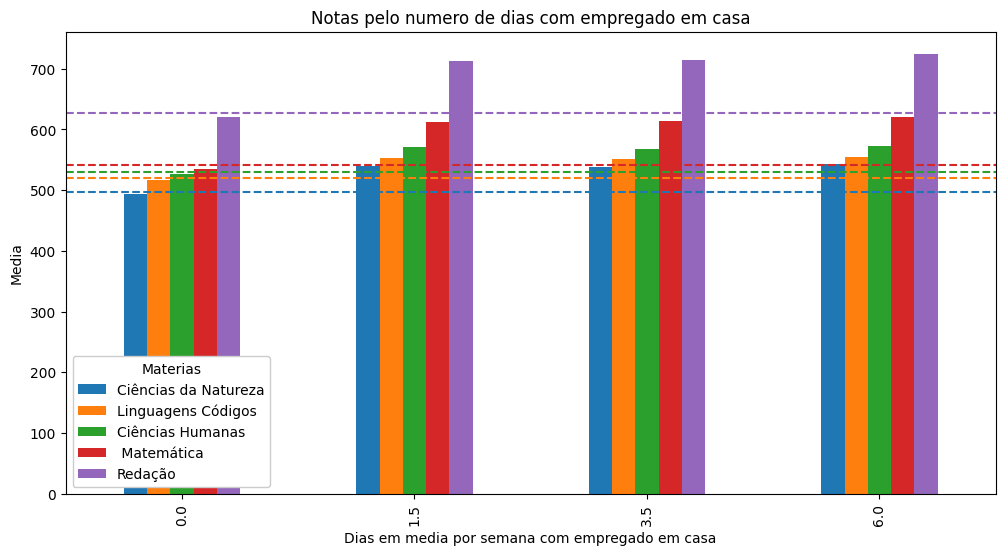

```python
# materias=['NU_NOTA_CN','NU_NOTA_LC','NU_NOTA_CH','NU_NOTA_MT','NU_NOTA_REDACAO']
# agrupado_empregado_dias=df_a1.groupby('Q007')[materias].mean(numeric_only=True)    #criando o grupo a ser analisado
# media_geral=df_a1[['NU_NOTA_CN','NU_NOTA_LC','NU_NOTA_CH','NU_NOTA_MT','NU_NOTA_REDACAO']].mean()          #tirando as medias

# agrupado_empregado_dias.plot(kind='bar', figsize=(12, 6))              #plotando
# plt.title('Notas pelo numero de dias com empregado em casa')
# plt.xlabel('Dias em media por semana com empregado em casa')
# plt.ylabel('Media')
# plt.legend(title='Materias', loc='lower left',framealpha=1,labels=nomes)

# #https://matplotlib.org/3.5.3/api/_as_gen/matplotlib.pyplot.html

# for i, mean in enumerate(media_geral):
#     plt.axhline(mean, color=f'C{i}', linestyle='--') #chatgpt

# print('Quantas pessoas em cada grupo:')  #ler outputs aqui
# print(df_a1['Q007'].value_counts(),'\n\n\n')
# print('Media de notas em materias especificas de cada grupo:')
# print(agrupado_empregado_dias,'\n\n\n')
# porcentagem(agrupado_empregado_dias,3,'dias com empregado em casa')
```

A distribuição de pessoas com ou sem acesso a empregados em casa é mostrado pela tabela:  
0.0---1765876  
1.5---87123  
6.0---48711  
3.5---19140  
Isso explica o porque das linhas pontilhadas, as médias das notas, estão tão próximas dos vestibulandos sem empregados em casa.

```
Q025
1    0.912928
0    0.087072
Name: proportion, dtype: float64
NU_NOTA_CN         0.075332
NU_NOTA_LC         0.098282
NU_NOTA_CH         0.088615
NU_NOTA_MT         0.126882
NU_NOTA_REDACAO    0.157491
dtype: float64
```

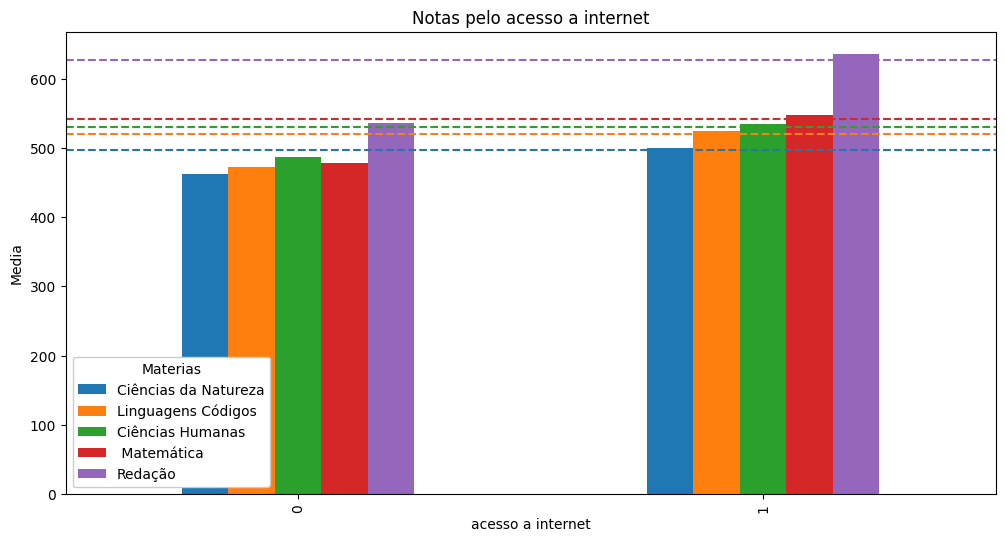

```python
# agrupado_internet=df_a1.groupby('Q025')[['NU_NOTA_CN','NU_NOTA_LC','NU_NOTA_CH','NU_NOTA_MT','NU_NOTA_REDACAO']].mean(numeric_only=True)        #criando o grupo a ser analisado
# media_geral=df_a1[['NU_NOTA_CN','NU_NOTA_LC','NU_NOTA_CH','NU_NOTA_MT','NU_NOTA_REDACAO']].mean()            #tirando as medias

# agrupado_internet.plot(kind='bar', figsize=(12, 6))              #plotando
# plt.title('Notas pelo acesso a internet')
# plt.xlabel('acesso a internet')
# plt.ylabel('Media')
# plt.legend(title='Materias', loc='lower left',framealpha=1,labels=nomes)

# #https://matplotlib.org/3.5.3/api/_as_gen/matplotlib.pyplot.html

# for i, mean in enumerate(media_geral):
#     plt.axhline(mean, color=f'C{i}', linestyle='--')

# #print(agrupado_internet)

# print(df_a1['Q025'].value_counts(normalize=True))    #olhando a porcentagem de pessoas com acesso
#                                                      #a internet
# print(1-(agrupado_internet.iloc[0]/agrupado_internet.iloc[1]))
```

Pessoa com acesso a internet estão muito próximos da media pois eles equivalem a 91% das pessoas, porém é visível que quem não tem acesso a internet está em um defict gigantesco

# VOLTAR A LER AQUI

Por fim, a última comparação em gráficos feitas foi tentando relacionar o número de aparelhos domésticos em casa com a média de nota dos grupos de pessoas.

Para que isso fosse feito, foi necessário agrupar as informações da base de dados do ENEM, na base original tinha respostas de perguntas como: • Na sua residência tem carro? • Na sua residência tem motocicleta? • Na sua residência tem geladeira? • Na sua residência tem freezer (independente ou segunda porta da geladeira)? • Na sua residência tem máquina de lavar roupa? (o tanquinho NÃO deve ser considerado) • Na sua residência tem forno micro-ondas?

Foram atribuídos um valor máximo de ‘’comodidades” um aluno poderia ter, esse valor é a soma do número total de perguntas de interesse, que equivale a 10, e para cada resposta não o aluno perderia 1 “ponto” assim chegaríamos a o número total de comodidades que o aluno tem em casa. Com isso, o que vemos é uma progressão quase que linear.

```
Diferença percentual entre as notas do grupo
com 0 comodidades e 1 comodidades
NU_NOTA_CN         0.003077
NU_NOTA_LC         0.024787
NU_NOTA_CH         0.015358
NU_NOTA_MT         0.009195
NU_NOTA_REDACAO    0.046665
dtype: float64



Diferença percentual entre as notas do grupo
com 0 comodidades e 2 comodidades
NU_NOTA_CN         0.017301
NU_NOTA_LC         0.055913
NU_NOTA_CH         0.037657
NU_NOTA_MT         0.038599
NU_NOTA_REDACAO    0.101399
dtype: float64



Diferença percentual entre as notas do grupo
com 0 comodidades e 3 comodidades
NU_NOTA_CN         0.035070
NU_NOTA_LC         0.080699
NU_NOTA_CH         0.059646
NU_NOTA_MT         0.070175
NU_NOTA_REDACAO    0.137898
dtype: float64



Diferença percentual entre as notas do grupo
com 0 comodidades e 4 comodidades
NU_NOTA_CN         0.054848
NU_NOTA_LC         0.105904
NU_NOTA_CH         0.083590
NU_NOTA_MT         0.104007
NU_NOTA_REDACAO    0.168990
```

[output cut: 52 more lines]

```
NU_NOTA_CH         0.176389
NU_NOTA_MT         0.255574
NU_NOTA_REDACAO    0.301412
dtype: float64



Diferença percentual entre as notas do grupo
com 0 comodidades e 10 comodidades
NU_NOTA_CN         0.168872
NU_NOTA_LC         0.192315
NU_NOTA_CH         0.179597
NU_NOTA_MT         0.262209
NU_NOTA_REDACAO    0.307067
dtype: float64
```

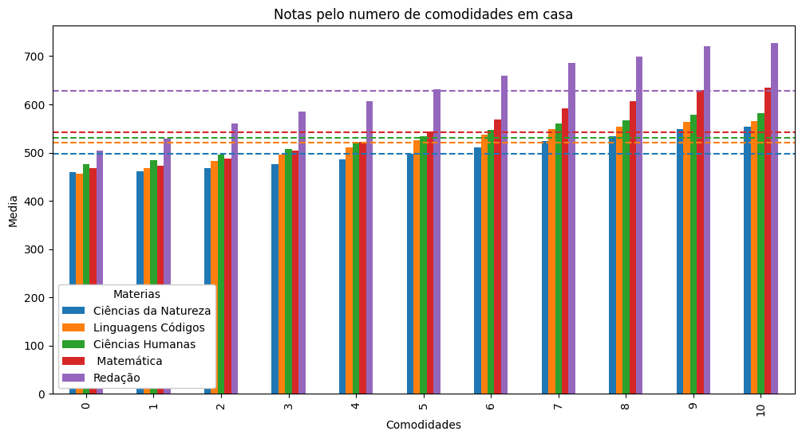

```python
agrupado_comodidades=df_a1.groupby('Comodidades')[['NU_NOTA_CN','NU_NOTA_LC','NU_NOTA_CH','NU_NOTA_MT','NU_NOTA_REDACAO']].mean()      #criando o grupo a ser analisado
media_geral=df_a1[['NU_NOTA_CN','NU_NOTA_LC','NU_NOTA_CH','NU_NOTA_MT','NU_NOTA_REDACAO']].mean()            #tirando as medias

agrupado_comodidades.plot(kind='bar', figsize=(12, 6))        #plotando
plt.title('Notas pelo numero de comodidades em casa')
plt.xlabel('Comodidades')
plt.ylabel('Media')
plt.legend(title='Materias', loc='lower left',framealpha=1,labels=nomes)

#https://matplotlib.org/3.5.3/api/_as_gen/matplotlib.pyplot.html

for i, mean in enumerate(media_geral):
    plt.axhline(mean, color=f'C{i}', linestyle='--')     #essas duas ultimas linhas chat gpt

porcentagem(agrupado_comodidades,10,'comodidades')
```

As médias progridem em ordem crescente de acordo com a quantidade de commodidades em casa, ou de melhor maneira 'facilitadores de vida', uma medida que pode ser explicada, pois com esses facilitadores em casas o aluno tem mais tempo livre, que ode ser ultilizado, tanto com estudos ou com lazer. Esse tempo livre, deve ser traduzido em melhores notas.

Plotando um gráfico para variação de nota por comodidade, fica claro que, além de termos uma relação quase que linear, mais uma vez consolida-se que redação e matemática são as matérias mais afetadas

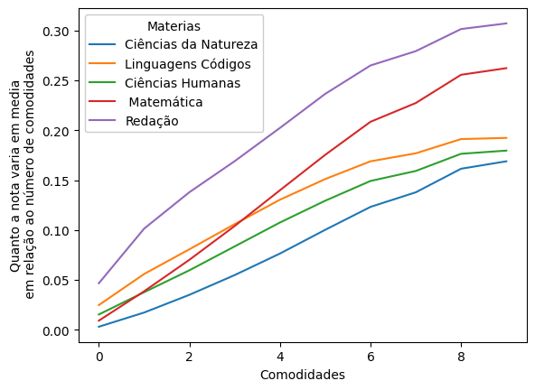

```python
a=[]
for i in range (1,11):
    a.append(1-(agrupado_comodidades.iloc[0]/agrupado_comodidades.iloc[i]))

plt.plot(a)
plt.legend(title='Materias', loc='upper left',framealpha=1,labels=nomes)
plt.ylabel('Quanto a nota varia em media\n em relação ao número de comodidades')
plt.xlabel('Comodidades')
```

Assim, podemos ter uma ampla visão de como todos os indicadores econômicos vistos no trabalho e que os mesmos estão positivamente relacionados com a notas em matérias do ENEM, quase em todos fatores

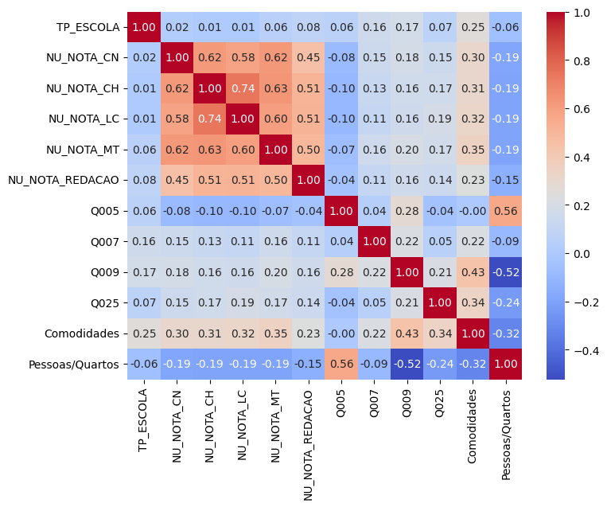

```python
correc=df_a1.corr()

plt.figure(figsize=(8, 6))
sns.heatmap(correc,cmap='coolwarm',annot=True,fmt='.2f') #checar o quanto cada indicador afeta a nota final

#https://seaborn.pydata.org/generated/seaborn.heatmap.html
```

Como o esperado todos indicadores socias implicam em uma melhor nota no ENEM, para quem tem melhores condições fincanceiras

O principal problema desse dado é que, os conteúdos dados na escola são de grande importância para o desenvolvimento mental dos alunos (https://editorarealize.com.br/editora/anais/fiped/2013/Trabalho_Comunicacao_oral_idinscrito_1040_3bbe862464859de050561c8cd0efa617.pdf), algo muito além do conteúdo que eles provem aos alunos. E a matemática em específico para o pensamento lógico e de resoluções de problemas, algo que está sendo provado deficitário, além do déficit normal dentre as outras matérias cobradas no ENEM o que vai afetar muito os alunos no futuro, muito além da capacidade do estudante de resolver contas e em qual faculdade o aluno vai conseguir entrar com a sua nota no ENEM, provavelmente até para resolução de adversidades que possam ser encontradas em seus futuros empregos.